# Tracing New Filtered NWs

Greg Cary

2023-02-22

```r
# Package names
packages <- c(
  # 'paxtoolsr','org.Hs.eg.db','HotNetvieweR','clusterProfiler',
  'synapser','igraph','tidygraph','tidyverse'
  )

# Load packages
invisible(lapply(packages, library, character.only = TRUE))

source(paste0(here::here(),'/../biodom_tally.R'))
source(paste0(here::here(),'/../biodom_enr.R'))
source(paste0(here::here(),'/../biodom_enr_plots.R'))

theme_set(theme_bw())
```

Grab relevant data from synapse, including: 1) Target Risk Scores (syn25575156) and Omics Scores (syn22758536)  
2) Biodomain Definitions (syn25428992)  
2) Risk-enriched Biodomain Terms (syn45824995) 3) Pathway Commons Full Graph, v12 (syn51080932)  
4) Human Protein Atlas tissue immunohistochemistry micro array data (syn51074598)  
7) SEA-AD single cell data (syn51080312)

```r
# target risk scores
scores <- read_csv(synTableQuery('select * from syn25575156', includeRowIdAndRowVersion = F)$filepath)
```

# Pathway Commons Network

Build NW objects based on filters

```r
# specify directed edge types
directed_edge_types = c("catalysis-precedes",
                        "controls-expression-of",
                        "controls-phosphorylation-of",
                        "controls-state-change-of",
                        "controls-transport-of"
                        )

# specify brain expressed gene lists
hpa.brain.tissues <- c(
 "caudate", "cerebellum", "cerebral cortex", "hippocampus",
 "hypothalamus", "pituitary gland", "dorsal raphe",
 "choroid plexus", "substantia nigra"
)

hpa.brain <- tissue.array %>%
  filter(
    Tissue %in% hpa.brain.tissues,
    Level %in% c('Low','Medium','High','Ascending','Descending'),
    Reliability %in% c('Enhanced','Supported','Approved') ) %>%
  pull(Gene.name) %>% unique()

tad.deg <- scores %>%
  filter(isScored_omics == 'Y', OmicsScore > 0) %>%
  pull(GeneName) %>% unique()

seaad.expr <- seaad %>%
  filter(mean > 1) %>%
  pull(gene) %>% unique()

brain.genes <- union(hpa.brain, tad.deg) %>% union(., seaad.expr)
```

Test SEA-AD filters for cell type expression annotation

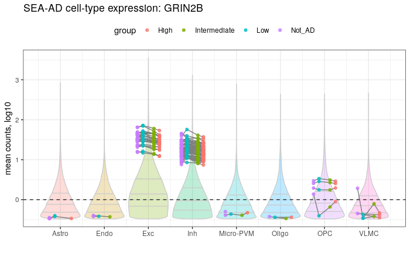

Generate cell type specific expression table

```r
cellTypeExpr <- seaad %>%

  # filter out low expression
  filter(mean > 1) %>%
  select(gene, broad, cellType, group) %>%

  # only keep genes that are detected above threshold in the same cell in multiple groups
  group_by(cellType) %>% filter(duplicated(gene)) %>% ungroup() %>%

  # retain only gene and broad cell type specification
  select(-cellType, -group) %>% distinct() %>%

  # pivot the table so there are 1's and 0's to indicate if a gene is expressed in each cell class
  mutate(val = 1) %>%
  pivot_wider(id_cols = gene, names_from = broad, values_from = val) %>%
  mutate(across(.cols = -gene, ~ if_else(is.na(.x), 0, .x))) %>%
  rename(Micro = `Micro-PVM`)
```

Annotate nodes with TREAT-AD scores and annotations

```r
net = pc.net

# edge directionality
x = tibble( edge = E(net)$interaction ) %>%
  mutate(
    directed = if_else(edge %in% directed_edge_types, 1, 0)
  )

igraph::edge_attr(net, "directed") <- x$directed

# Brain expression evidence
x = tibble( node = V(net) %>% names ) %>%
  mutate(
    hpa = if_else(node %in% hpa.brain, 1, 0)
    , ampad_deg = if_else(node %in% tad.deg, 1, 0)
    , seaad = if_else(node %in% seaad.expr, 1, 0)
    , brain_exp = if_else(node %in% brain.genes, 1, 0)
  )

for(i in 2:ncol(x)){
  igraph::vertex_attr(net, names(x)[i], index = igraph::V(net)) <- x %>% pull(i)
}

# Overall TREAT-AD Target Risk Score (TRS)
x = tibble( node = V(net) %>% names ) %>%
  left_join(
    ., scores %>% filter(!duplicated(GeneName)) %>% select(node = GeneName, Overall) %>% distinct()
    , by = 'node'
    , na_matches = "never")
if( all( x$node != names(V(net)) ) ){ cat("Network Node IDs and annotation table IDs dont match") }

igraph::vertex_attr(net, "TargetRiskScore", index = igraph::V(net)) <- x$Overall

# Omics Effect Scores (i.e. directionality)
x = tibble( node = V(net) %>% names ) %>%
  left_join(
    ., omics %>% filter(!duplicated(GName)) %>% select(node = GName, RNA_TE, Pro_TE) %>% distinct()
    , by = 'node'
    , na_matches = "never")
if( all( x$node != names(V(net)) ) ){ cat("Network Node IDs and annotation table IDs dont match") }

igraph::vertex_attr(net, "RNA_EffectScore", index = igraph::V(net)) <- x$RNA_TE
igraph::vertex_attr(net, "Pro_EffectScore", index = igraph::V(net)) <- x$Pro_TE

# Cell Type Expression
x = tibble( node = V(net) %>% names ) %>%
  left_join(
    ., cellTypeExpr %>% filter(!duplicated(gene)) %>% rename(node = gene) %>% distinct()
    , by = 'node'
    , na_matches = "never")

for(i in 2:ncol(x)){
  igraph::vertex_attr(net, names(x)[i], index = igraph::V(net)) <- x %>% pull(i)
}

# produce data frame versions of network, node annotations, and edge annotations
net.tbl <- igraph::as_data_frame(net)

v.attr <- tibble( na = vertex.attributes(net) ) %>%
  t() %>% as_tibble(rownames = NA, .name_repair = 'unique') %>% unnest(everything()) %>%
  rename_with(., ~names(vertex.attributes(net)), everything())
```

```
* `` -> ...1
* `` -> ...2
* `` -> ...3
* `` -> ...4
* `` -> ...5
* ...
```

```r
e.attr <- tibble( ea = edge.attributes(net) ) %>%
  t() %>% as_tibble(rownames = NA, .name_repair = 'unique') %>% unnest(everything()) %>%
  rename_with(., ~names(edge.attributes(net)), everything())
```

```
* `` -> ...1
* `` -> ...2
* `` -> ...3
* `` -> ...4
* `` -> ...5
* ...
```

Generate filtered networks

```r
# NW versions
# 1) full
nw <- net

# 2) full.directed
nw.dir <- igraph::subgraph.edges(
  net,
  igraph::E(net)[ igraph::E(net)$directed == 1 ],
  delete.vertices = T
  ) %>%
  as.directed(mode = 'arbitrary')

# 3) filt.edge
nw.eFilt <- igraph::subgraph.edges(
  net,
  igraph::E(net)[ igraph::E(net)$n_edge_evidence > 1 ],
  delete.vertices = T
  )

# 4) filt.node
nw.nFilt <- igraph::delete_vertices(
  net,
  igraph::V(net)[ igraph::V(net)$brain_exp == 0 ]
)

# 5) filt.edge >> node
nw.enFilt <- igraph::delete_vertices(
  nw.eFilt,
  igraph::V(nw.eFilt)[ igraph::V(nw.eFilt)$brain_exp == 0 ]
)

# 6) filt.node >> edge
nw.neFilt <- igraph::subgraph.edges(
  nw.nFilt,
  igraph::E(nw.nFilt)[ igraph::E(nw.nFilt)$n_edge_evidence > 1 ],
  delete.vertices = T
)
```

Calculate NW stats

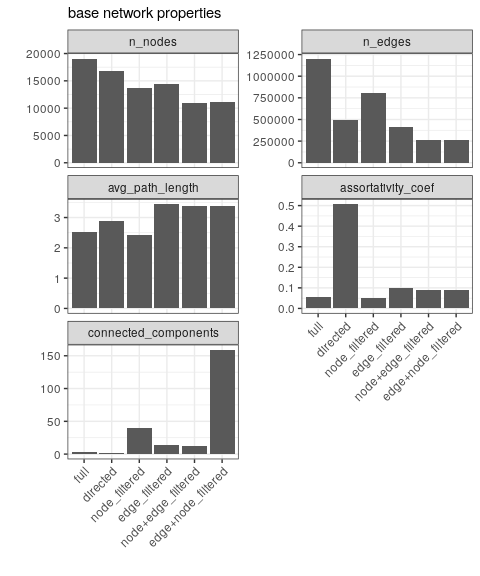

```r
nw.stats <- tibble(
  network = c('full','directed','edge_filtered','node_filtered','edge+node_filtered','node+edge_filtered'),
  n_nodes = c(
    nw %>% V %>% length,
    nw.dir %>% V %>% length,
    nw.eFilt %>% V %>% length,
    nw.nFilt %>% V %>% length,
    nw.enFilt %>% V %>% length,
    nw.neFilt %>% V %>% length    ),
  n_edges = c(
    nw %>% E %>% length,
    nw.dir %>% E %>% length,
    nw.eFilt %>% E %>% length,
    nw.nFilt %>% E %>% length,
    nw.enFilt %>% E %>% length,
    nw.neFilt %>% E %>% length     ),
  avg_path_length = c(
    nw %>% average.path.length,
    nw.dir %>% average.path.length,
    nw.eFilt %>% average.path.length,
    nw.nFilt %>% average.path.length,
    nw.enFilt %>% average.path.length,
    nw.neFilt %>% average.path.length     ),
  assortativity_coef = c(
    nw %>% assortativity(., types1 = V(.)),
    nw.dir %>% assortativity(., types1 = V(.)),
    nw.eFilt %>% assortativity(., types1 = V(.)),
    nw.nFilt %>% assortativity(., types1 = V(.)),
    nw.enFilt %>% assortativity(., types1 = V(.)),
    nw.neFilt %>% assortativity(., types1 = V(.))     ),
  connected_components = c(
    nw %>% no.clusters,
    nw.dir %>% no.clusters,
    nw.eFilt %>% no.clusters,
    nw.nFilt %>% no.clusters,
    nw.enFilt %>% no.clusters,
    nw.neFilt %>% no.clusters    )
  )

nw.stats %>%
  pivot_longer(cols = -network, names_to = 'properties', values_to = 'val') %>%
  mutate(properties = factor(properties,
                             levels = c('n_nodes','n_edges', 'avg_path_length','assortativity_coef','connected_components'))
         , network = factor(network, levels = c('full','directed','node_filtered','edge_filtered','node+edge_filtered', 'edge+node_filtered'))) %>%
  ggplot(aes(network, val)) +
  geom_bar(stat = 'identity', position = 'dodge')+
  theme(legend.position = 'top',
        axis.text.x = element_text(angle = 45, hjust = 1, vjust = 1))+
  labs(y = '',x = '', subtitle = 'base network properties')+
  facet_wrap(~properties, scales = 'free_y', ncol = 2)
```

```r
write.graph(net,
            file = paste0(here::here(), '/data/annotated_base_network.graphml'),
            format = 'graphml')

synLogin()
```

```
Welcome, Greg Cary!NULL
```

```r
foo <- synStore(File(
  paste0(here::here(), '/data/annotated_base_network.graphml'),
  parent = 'syn51080283'))
```

[output not shown]

[output cut: 61 more lines]

[output not shown]

# Gene list to trace

Distribution of term NES values at different significance levels

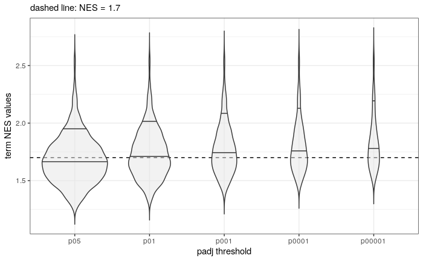

What are the lengths of the input gene lists (i.e. leading edge genes from terms enriched with different thresholds). Below, the NES threshold is >1.7

| Biodomain | p01 | p001 | p0001 | p00001 | p01_nes | p001_nes | p0001_nes | p00001_nes |
| --- | --- | --- | --- | --- | --- | --- | --- | --- |
| Apoptosis | 741 | 689 | 652 | 419 | 375 | 344 | 278 | 265 |
| APP Metabolism | 119 | 97 | 48 | 47 | 119 | 97 | 48 | 47 |
| Autophagy | 471 | 467 | 316 | 316 | 92 | 72 | 57 | 57 |
| Cell Cycle | 1033 | 831 | 791 | 781 | 499 | 498 | 498 | 497 |
| DNA Repair | 66 | 66 | 0 | 0 | 0 | 0 | 0 | 0 |
| Endolysosome | 1062 | 1003 | 937 | 913 | 748 | 735 | 692 | 676 |
| Epigenetic | 387 | 376 | 0 | 0 | 26 | 0 | 0 | 0 |
| Immune Response | 1623 | 1492 | 1333 | 1115 | 845 | 746 | 650 | 607 |
| Lipid Metabolism | 1576 | 1414 | 1331 | 1231 | 819 | 805 | 692 | 657 |
| Metal Binding and Homeostasis | 734 | 731 | 725 | 702 | 62 | 34 | 26 | 0 |

[output cut: 10 more lines]

Specify input gene list from leading edge genes from significantly (padj < 0.01 & NES > 1.7) enriched **APP Metabolism** terms

```r
input.gene.list <- enr.bd %>%
  filter(
    Biodomain == 'APP Metabolism',
    padj < 0.01,
    NES > 1.7
  ) %>%
  pull(leadingEdge_genes) %>%
  unlist() %>%
  unique()
```

# Path Tracing

```r
source(paste0(here::here(), '/scripts/igraph_NW_exp_functions.R'))

app.paths = short_paths(
    tnet = nw,
    target = 'APP',
    targets = input.gene.list,
    sentinals = input.gene.list,
    cores = 1)
```

The (modified) tracing function works. Trace networks with/without filters using batch jobs.

The batch jobs are run using the **biodomain_network_tracing_and_kda.R** script. This script takes input parameters including a number (1..19) specifying which biodomain to trace, and flags to force the use of directed edges, filter nodes without evidence of brain expression, and filter edges without at least 2 different PubMed IDs confirming the link.

The Biodomains with traced NW analyzed by wKDA include:  
1) APP Metabolism  
2) Tau Homeostasis  
3) Immune Response  
4) Mitochondrial Metabolism 5) Lipid Metabolism

# Biodom NW analyses

## APP Metabolism

## Tau Homeostasis

## Immune Response

## Mitochondrial Metabolism

# Lipid Metabolism